# Introduction to T-Tests in R

# Introduction

T-tests are fundamental statistical tools for comparing means between groups. In this notebook, we’ll explore two common variants: **Student’s t-test** and **Welch’s t-test**. Understanding when to use each is crucial for sound statistical practice.

# Part 1: Student’s T-Test

## When to Use It

Student’s t-test assumes: - The two groups are normally distributed (when the sample size is small; note that when the sample size is sufficiently large, then the means will be normally distributed thanks to CLT) - The two groups have **equal variances** - Samples are independent

## Example: Plant Growth

Let’s compare plant heights under two different light conditions.

```r
set.seed(42)

# Simulate plant height data (in cm)
light_condition_A <- rnorm(n = 30, mean = 25, sd = 3.5)
light_condition_B <- rnorm(n = 30, mean = 23, sd = 3.2)

# Create a data frame
plant_data <- tibble(
  height = c(light_condition_A, light_condition_B),
  condition = rep(c("A", "B"), each = 30)
)
```

## Running Student’s T-Test

```r
# Method 1: Using base R
t_test_student <- t.test(height ~ condition,
                         data = plant_data,
                         var.equal = TRUE)
t_test_student
```

```
##
##  Two Sample t-test
##
## data:  height by condition
## t = 2.6049, df = 58, p-value = 0.01166
## alternative hypothesis: true difference in means between group A and group B is not equal to 0
## 95 percent confidence interval:
##  0.6089969 4.6513253
## sample estimates:
## mean in group A mean in group B
##        25.24005        22.60989
```

## Understanding the Output

```r
cat("Test Statistic (t):", round(t_test_student$statistic, 3), "\n")
```

```
## Test Statistic (t): 2.605
```

```r
cat("Degrees of Freedom:", round(t_test_student$parameter, 1), "\n")
```

```
## Degrees of Freedom: 58
```

```r
cat("P-value:", round(t_test_student$p.value, 4), "\n")
```

```
## P-value: 0.0117
```

### What This Means

- **t-statistic:** The ratio of the mean difference to the standard error.
- **p-value:** The probability of observing this (or a more extreme) difference if the null hypothesis is true.

# Part 2: Welch’s T-Test

## When to Use It

Welch’s t-test is more robust because it: - Does NOT assume equal variances - Still assumes approximate normality and independence - Works well when sample sizes differ between groups

## Example: Student Test Scores

Let’s simulate how two different teaching methods influence student outcomes (note that there is unequal variability in outcomes).

```r
set.seed(123)

# Method 1: Less variable outcomes
method1_scores <- rnorm(n = 25, mean = 78, sd = 5)

# Method 2: More variable outcomes
method2_scores <- rnorm(n = 35, mean = 80, sd = 12)

# Create data frame
test_data <- tibble(
  score = c(method1_scores, method2_scores),
  method = rep(c("Method 1", "Method 2"), c(25, 35))
)
```

## Visualizing Unequal Variances

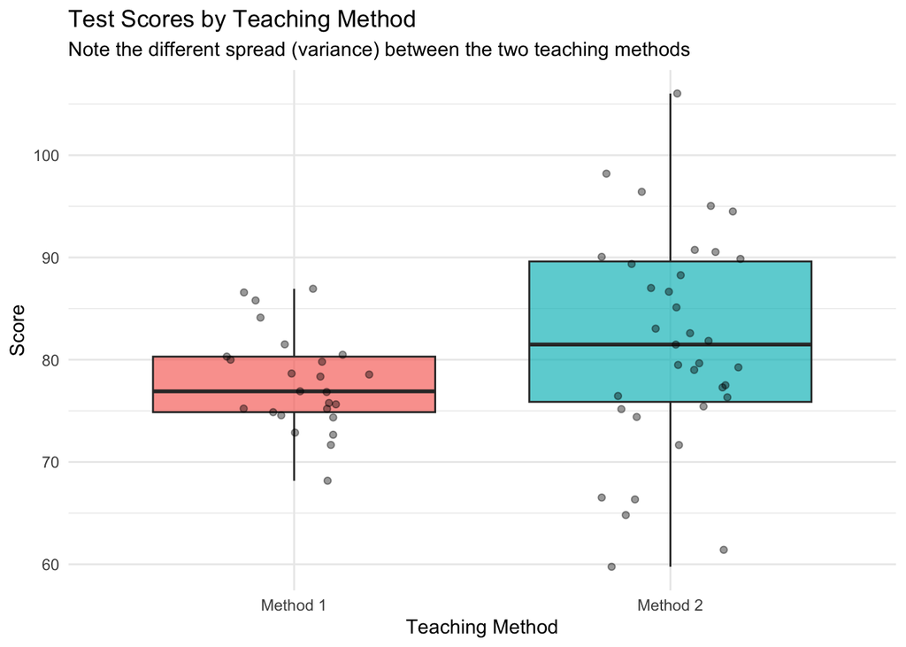

```r
test_data %>%
  ggplot(aes(x = method, y = score, fill = method)) +
  geom_boxplot(alpha = 0.7) +
  geom_jitter(width = 0.2, alpha = 0.4) +
  theme_minimal() +
  theme(legend.position = "none") +
  labs(title = "Test Scores by Teaching Method",
       subtitle = "Note the different spread (variance) between the two teaching methods",
       x = "Teaching Method", y = "Score")
```

## Running Welch’s T-Test

```r
# Welch's t-test (the default in R)
t_test_welch <- t.test(score ~ method,
                       data = test_data,
                       var.equal = FALSE)  # This is the default
t_test_welch
```

```
##
##  Welch Two Sample t-test
##
## data:  score by method
## t = -1.8643, df = 49.908, p-value = 0.06817
## alternative hypothesis: true difference in means between group Method 1 and group Method 2 is not equal to 0
## 95 percent confidence interval:
##  -7.8988388  0.2944765
## sample estimates:
## mean in group Method 1 mean in group Method 2
##               77.83335               81.63553
```

## Comparing the Two Approaches

```r
# Student's t-test (assuming equal variances)
t_test_student2 <- t.test(score ~ method,
                          data = test_data,
                          var.equal = TRUE)

cat("STUDENT'S T-TEST (assumes equal variances)\n")
```

```
## STUDENT'S T-TEST (assumes equal variances)
```

```r
cat("t-statistic:", round(t_test_student2$statistic, 4), "\n")
```

```
## t-statistic: -1.6631
```

```r
cat("df:", round(t_test_student2$parameter, 2), "\n")
```

```
## df: 58
```

```r
cat("p-value:", round(t_test_student2$p.value, 4), "\n\n")
```

```
## p-value: 0.1017
```

```r
cat("WELCH'S T-TEST (does NOT assume equal variances)\n")
```

```
## WELCH'S T-TEST (does NOT assume equal variances)
```

```r
cat("t-statistic:", round(t_test_welch$statistic, 4), "\n")
```

```
## t-statistic: -1.8643
```

```r
cat("df:", round(t_test_welch$parameter, 2), "\n")
```

```
## df: 49.91
```

```r
cat("p-value:", round(t_test_welch$p.value, 4), "\n")
```

```
## p-value: 0.0682
```

### Key Differences

Notice that Welch’s t-test has lower degrees of freedom (it’s more conservative) and adjusts for the unequal variances. When variances differ substantially, Welch’s p-value is often more reliable.

Many statisticians now recommend **Welch’s t-test as the default** because: - It performs well even when variances are equal - It’s robust against violations of the equal variance assumption - Sample sizes are often unequal in real data - The disadvantage (slightly less power with equal variances) is minor